# Assignment_3-1_Titanic_Kelsey-Liu

## Assignment 3-1: Titanic Survival Prediction

### Kelsey Liu

*2023-02-07*

### 01. Titanic Project

Step 1: Preprocess the data. Selection/generation/ transformation of categorical variables, useful variables etc all your discretion.

Step 2: Build your models: Please build classification models in Python to predict the Survived binary status assigned to a passenger. When writing the code associated with each model, please have the first part produce and save the model, followed by a second part that loads and applies the model.

Step 3: Test your models using the data found within the "Holdout_testing" file. Save the results of the final model (remember you will only predict the Survived column in holdout test set with your best model results) in a single, separate CSV titled "Titanic Results from" *insert your name or UChicago net ID.

Step 4: Submit your work: Please submit all of your code for cleaning, prepping, and modeling your data, your "Results" file, a brief write-up comparing the pros and cons of the modeling techniques you used (no more than a paragraph). Your work will be scored on techniques used (appropriateness and complexity), model performance - measured by accuracy precision and F score - on the data hold out, an understanding of the techniques you compared in your write-up, and your overall code.

**Data Dictionary**

1. survival Survival: 0 = No, 1 = Yes
2. pclass: Ticket class 1 = 1st, 2 = 2nd, 3 = 3rd
3. sex: Sex
4. Age: Age in years
5. sibsp: # of siblings / spouses aboard the Titanic
6. parch: # of parents / children aboard the Titanic
7. ticket: Ticket number
8. fare: Passenger fare
9. cabin: Cabin number
10. embarked: Port of Embarkation C = Cherbourg, Q = Queenstown, S = Southampton

```python
%matplotlib inline
import numpy as np
import pandas as pd
from scipy import stats
import matplotlib.pyplot as plt
import seaborn as sns
from sklearn.model_selection import train_test_split

# Importing Classifier Modules
from sklearn.linear_model import LogisticRegression
from sklearn.svm import SVC, LinearSVC
from sklearn.neighbors import KNeighborsClassifier
from sklearn.tree import DecisionTreeClassifier
from sklearn.ensemble import RandomForestClassifier
from sklearn.naive_bayes import GaussianNB
from sklearn.linear_model import Perceptron
from sklearn.linear_model import SGDClassifier
from sklearn.ensemble import GradientBoostingClassifier

pd.set_option("display.max_columns", None)
plt.style.use("ggplot")
%load_ext lab_black
```

```
The lab_black extension is already loaded. To reload it, use:
  %reload_ext lab_black
```

```python
df = pd.read_csv("train.csv")

df.head()
```

|  | PassengerId | Survived | Pclass | Name | Sex | Age | SibSp | Parch | Ticket | Fare | Cabin | Embarked |
| --- | --- | --- | --- | --- | --- | --- | --- | --- | --- | --- | --- | --- |
| 0 | 1 | 0 | 3 | Braund, Mr. Owen Harris | male | 22.0 | 1 | 0 | A/5 21171 | 7.2500 | NaN | S |
| 1 | 2 | 1 | 1 | Cumings, Mrs. John Bradley (Florence Briggs Th... | female | 38.0 | 1 | 0 | PC 17599 | 71.2833 | C85 | C |
| 2 | 3 | 1 | 3 | Heikkinen, Miss. Laina | female | 26.0 | 0 | 0 | STON/O2. 3101282 | 7.9250 | NaN | S |
| 3 | 4 | 1 | 1 | Futrelle, Mrs. Jacques Heath (Lily May Peel) | female | 35.0 | 1 | 0 | 113803 | 53.1000 | C123 | S |
| 4 | 5 | 0 | 3 | Allen, Mr. William Henry | male | 35.0 | 0 | 0 | 373450 | 8.0500 | NaN | S |

```python
# df.info()
df.isnull().sum()
```

```
PassengerId      0
Survived         0
Pclass           0
Name             0
Sex              0
Age            177
SibSp            0
Parch            0
Ticket           0
Fare             0
Cabin          687
Embarked         2
dtype: int64
```

```python
# df['Parch'].value_counts()
df["Embarked"].value_counts()
```

```
S    644
C    168
Q     77
Name: Embarked, dtype: int64
```

```python
# Since there are only 2 missing values in df['Embarked'], we simply impute it with 'S', which is dominant in the dataset,
df["Embarked"] = df["Embarked"].fillna("S")
```

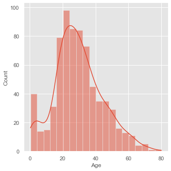

```python
sns.displot(df[df["Age"].notnull()]["Age"], kde=True)

plt.show()
```

```python
df["Age"].describe()
```

```
count    714.000000
mean      29.699118
std       14.526497
min        0.420000
25%       20.125000
50%       28.000000
75%       38.000000
max       80.000000
Name: Age, dtype: float64
```

```python
# Fill NaN values using an interpolation method
df["Age"] = df["Age"].interpolate()
# Check again the distribution using .describe()
df["Age"].describe()
```

```
count    891.000000
mean      29.726061
std       13.902353
min        0.420000
25%       21.000000
50%       28.500000
75%       38.000000
max       80.000000
Name: Age, dtype: float64
```

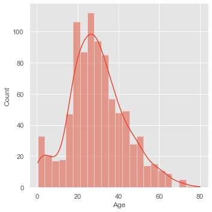

```python
# Check again the distribution through distplot, which is quite similar to the original one.
sns.displot(df["Age"], kde=True)
plt.show()
```

```python
len(df["Cabin"].unique())
```

```
148
```

```python
# Since there are 148 unique values (among 204 values) in cabin,
# but at the same time 687 missing values, it's best we just drop this column.
df = df.drop("Cabin", axis=1)
```

```python
# Check again: df.isna().sum() - No missing value anymore
df.head()
# Decide which features to keep in our model, especially for categorical variable: is it informative enough to be kept?
# if yes, do one-hot encoding (dummy variables); if not, drop it.
```

|  | PassengerId | Survived | Pclass | Name | Sex | Age | SibSp | Parch | Ticket | Fare | Embarked |
| --- | --- | --- | --- | --- | --- | --- | --- | --- | --- | --- | --- |
| 0 | 1 | 0 | 3 | Braund, Mr. Owen Harris | male | 22.0 | 1 | 0 | A/5 21171 | 7.2500 | S |
| 1 | 2 | 1 | 1 | Cumings, Mrs. John Bradley (Florence Briggs Th... | female | 38.0 | 1 | 0 | PC 17599 | 71.2833 | C |
| 2 | 3 | 1 | 3 | Heikkinen, Miss. Laina | female | 26.0 | 0 | 0 | STON/O2. 3101282 | 7.9250 | S |
| 3 | 4 | 1 | 1 | Futrelle, Mrs. Jacques Heath (Lily May Peel) | female | 35.0 | 1 | 0 | 113803 | 53.1000 | S |
| 4 | 5 | 0 | 3 | Allen, Mr. William Henry | male | 35.0 | 0 | 0 | 373450 | 8.0500 | S |

```python
df = df.drop(["PassengerId", "Name", "Ticket"], axis=1)
df.head()
```

|  | Survived | Pclass | Sex | Age | SibSp | Parch | Fare | Embarked |
| --- | --- | --- | --- | --- | --- | --- | --- | --- |
| 0 | 0 | 3 | male | 22.0 | 1 | 0 | 7.2500 | S |
| 1 | 1 | 1 | female | 38.0 | 1 | 0 | 71.2833 | C |
| 2 | 1 | 3 | female | 26.0 | 0 | 0 | 7.9250 | S |
| 3 | 1 | 1 | female | 35.0 | 1 | 0 | 53.1000 | S |
| 4 | 0 | 3 | male | 35.0 | 0 | 0 | 8.0500 | S |

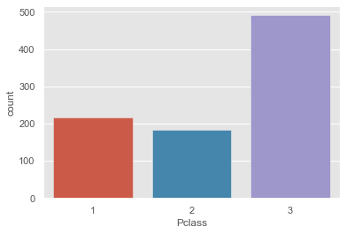

```python
sns.countplot(x=df["Pclass"])
plt.show()
```

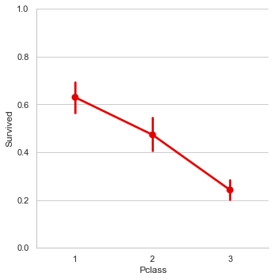

```python
sns.set(style="whitegrid")
g = sns.PairGrid(data=df, x_vars=["Pclass"], y_vars="Survived", height=5)
g.map(sns.pointplot, color=sns.xkcd_rgb["red"])
g.set(ylim=(0, 1))
plt.show()

# Shows the relationship between Pclass and Survived, indicating "Pclass" is fairly useful in predicting "Survived" column.
```

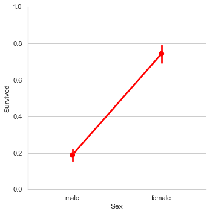

```python
h = sns.PairGrid(data=df, x_vars=["Sex"], y_vars="Survived", height=5)
h.map(sns.pointplot, color="red")
h.set(ylim=(0, 1))
plt.show()

# Shows the relationship between Sex and Survived, indicating "Sex" is fairly useful in predicting "Survived" column.
```

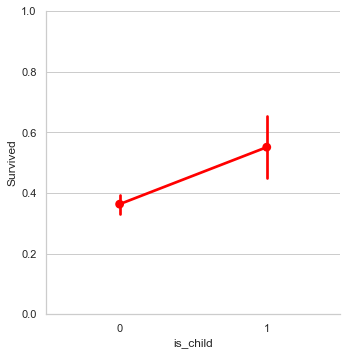

```python
# As Age is a numerical variable instead of categorical variable, we can create a new categorical column using age info.
df["is_child"] = df["Age"].apply(lambda x: 1 if x <= 15 else 0)

h = sns.PairGrid(data=df, x_vars=["is_child"], y_vars="Survived", height=5)
h.map(sns.pointplot, color="red")
h.set(ylim=(0, 1))
plt.show()

# Shows the relationship between is_child and Survived, indicating "is_child" is fairly useful in predicting "Survived" column.
```

```python
# As we can see that a huge portion of passenger went alone by looking at 'Parch' and 'SibSp',
# we are more concerned if a passenger was alone or went with any family members.
# therefore, we can create a new column called 'family' to combine 'Parch' and 'SibSp'.

df["family"] = df["SibSp"] + df["Parch"]
df = df.drop(["SibSp", "Parch"], axis=1)
```

```python
df["is_alone"] = df["family"].apply(lambda x: 1 if x == 0 else 0)
```

```python
# Create dummy variable for sex, we can either change female/ male to 1 and 0,
# or we can create a new column 'is_female' to make it easier to read
df["is_female"] = df["Sex"].apply(lambda x: 1 if x == "female" else 0)
df = df.drop("Sex", axis=1)
df.head()
```

|  | Survived | Pclass | Age | Fare | Embarked | is_child | family | is_alone | is_female |
| --- | --- | --- | --- | --- | --- | --- | --- | --- | --- |
| 0 | 0 | 3 | 22.0 | 7.2500 | S | 0 | 1 | 0 | 0 |
| 1 | 1 | 1 | 38.0 | 71.2833 | C | 0 | 1 | 0 | 1 |
| 2 | 1 | 3 | 26.0 | 7.9250 | S | 0 | 0 | 1 | 1 |
| 3 | 1 | 1 | 35.0 | 53.1000 | S | 0 | 1 | 0 | 1 |
| 4 | 0 | 3 | 35.0 | 8.0500 | S | 0 | 0 | 1 | 0 |